# Майнор "Интеллектуальный анализ данных"

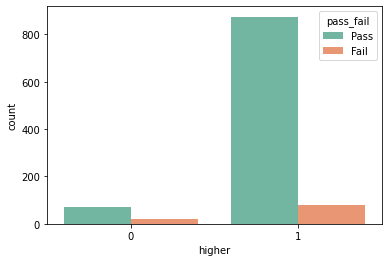

```python
sb.countplot(data=high_corr_data, x="higher", hue="pass_fail", palette='Set2')
```

- Можно заметить, что большинство, кто решил получать высшее образование, успешно сдают экзамены.

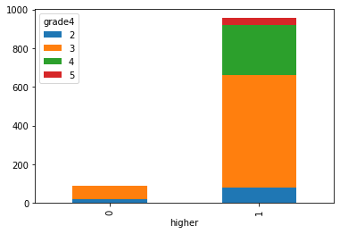

```python
fp_h = high_corr_data.groupby(['higher'])['grade4'].value_counts().unstack()
fp_h.plot(kind = 'bar', stacked = True)
```

- Также смотря на разбивку по оценкам, можно предсказать, что также те, кто решил получать высшее образование - получает хорошие баллы.

```python
# Medu: уровень образования матери

fp_medu = high_corr_data.groupby(['Medu'])['pass_fail'].value_counts().unstack()
fp_medu
```

| pass_fail Medu | Fail | Pass |
| --- | --- | --- |
| 0 | NaN | 9.0 |
| 1 | 25.0 | 177.0 |
| 2 | 26.0 | 263.0 |
| 3 | 28.0 | 210.0 |
| 4 | 21.0 | 285.0 |

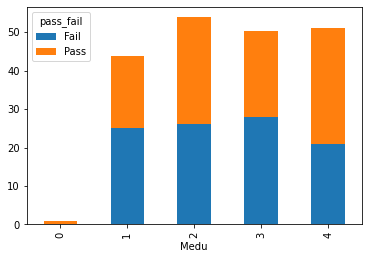

```python
fp_medu = pd.crosstab(high_corr_data.Medu, high_corr_data.pass_fail).apply(lambda x: x/x.sum() * 100)
fp_medu.plot(kind = 'bar', stacked = True)
```

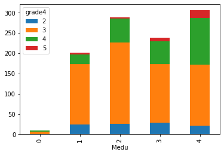

```python
fp_m = high_corr_data.groupby(['Medu'])['grade4'].value_counts().unstack()
fp_m.plot(kind = 'bar', stacked = True)
```

- По графику образования матери можно предсказать, что большее кол-во отличных оценок будут получать те, чья мама меет высшее образование.
- Студенты, чья мама закончила 5-9 классов, будут иметь больше всего троек.

```python
# studytime: кол-во часов на учебу в неделю

fp_studytime = high_corr_data.groupby(['pass_fail'])['studytime'].value_counts().unstack()
fp_studytime
```

| studytime pass_fail | 1 | 2 | 3 | 4 |
| --- | --- | --- | --- | --- |
| Fail | 40 | 48 | 7 | 5 |
| Pass | 277 | 455 | 155 | 57 |

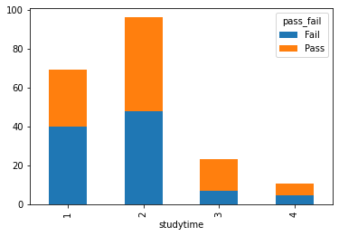

```python
fp_stt = pd.crosstab(high_corr_data.studytime, high_corr_data.pass_fail).apply(lambda x: x/x.sum() * 100)
fp_stt.plot(kind = 'bar', stacked = True)
```

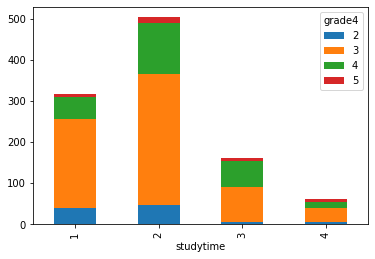

```python
fp_st = high_corr_data.groupby(['studytime'])['grade4'].value_counts().unstack()
fp_st.plot(kind = 'bar', stacked = True)
```

- Можно предсказать, что те студенты, кто потратит на учебу от 5 - 10+ часов, их шанты получить хорошую и отличную оценку высоки, а низкую - крайне малы, однако также велика велоятность получить 3.

```python
# schoolsup: доп. помощь в учебе

fp_schoolsup = high_corr_data.groupby(['pass_fail'])['schoolsup'].value_counts().unstack()
fp_schoolsup
```

| schoolsup pass_fail | 0 | 1 |
| --- | --- | --- |
| Fail | 88 | 12 |
| Pass | 837 | 107 |

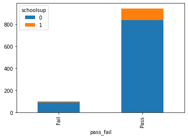

```python
fp_schoolsup.plot(kind = 'bar', stacked = True)
```

- Лишь маленький проент студентов, которым помогают, не сдают предмет.
- Многим студентам не нужна помощь, тк они итак успешны.

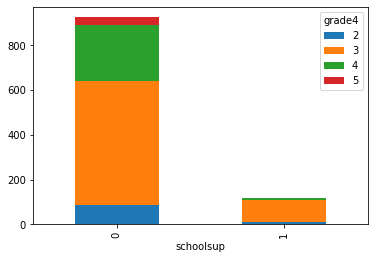

```python
fp_ss = high_corr_data.groupby(['schoolsup'])['grade4'].value_counts().unstack()
fp_ss.plot(kind = 'bar', stacked = True)
```

- Можно предсказать, что студенты, которм помогают, всяко сдадут на утвердительную оценку, процент несдачи крайне мал.

```python
# Dalc: потребление алкоголя в будни

fp_dalc = high_corr_data.groupby(['pass_fail'])['Dalc'].value_counts().unstack()
fp_dalc
```

| Dalc pass_fail | 1 | 2 | 3 | 4 | 5 |
| --- | --- | --- | --- | --- | --- |
| Fail | 62 | 26 | 3 | 5 | 4 |
| Pass | 667 | 168 | 66 | 21 | 22 |

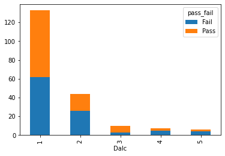

```python
fp_da = pd.crosstab(high_corr_data.Dalc, high_corr_data.pass_fail).apply(lambda x: x/x.sum() * 100)
fp_da.plot(kind = 'bar', stacked = True)
```

- На графике видно, что шансы несдачи повышаются у тех студентов, кто употребляет большое кол-во алкоголя(4-5), а также те, кто пьют средне(2).

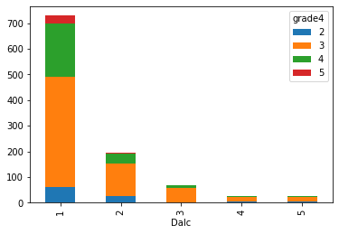

```python
fp_d = high_corr_data.groupby(['Dalc'])['grade4'].value_counts().unstack()
fp_d.plot(kind = 'bar', stacked = True)
```

- Можно предсказать, что у студента выше шанс получить отличную и хорошую оценку, если он мало пьет.

### Задание * (бонусное)

Дополнительное исследование данных и выводы положительно скажутся на оценке.

# Дополнительный анализ и предсказание оценок (4х балльная система)

```python
import sklearn
from sklearn.linear_model import LinearRegression
from sklearn.metrics import mean_squared_error , r2_score
```

1) Во-первых, очищаю данные от выбросов.

```python
# Q1 = data.quantile(0.25) # makes too small dataset
# Q3 = data.quantile(0.75)
Q1 = data.quantile(0.20)
Q3 = data.quantile(0.90)
IQR = Q3 - Q1

df_out = data[~((data < (Q1 - 1.5 * IQR)) |(data > (Q3 + 1.5 * IQR))).any(axis=1)]
print(df_out.shape)
```

```
(733, 38)
```

```python
# pred_data = df_out.loc[:, ['absences','grade4']] # точность 0.366...
pred_data = df_out.loc[:, ['alc_av_consump','grade4']] # точность 0.368...
```

```python
x = pred_data.iloc[:,0].values
y = pred_data.iloc[:,1].values
# print(x)
# print(y)
```

```python
# преобразую 2D-массива в 1D-массив
array = x.reshape(-1,1)
# print (array)
```

```python
from sklearn.model_selection import train_test_split
x_train, x_test, y_train, y_test = train_test_split(array,y,test_size=.25,random_state=105)
```

- test_size представляет данные, которые нужны для тестирования.
- random_state используется для создания одного и того же набора точек обучающих и тестовых данных для каждого разбиения.

```python
# создания модели линейной регрессии
lm = LinearRegression()
lm.fit(x_train,y_train)
y_train_pred = lm.predict(x_train)
y_test_pred = lm.predict(x_test)
```

```python
df = pd.DataFrame(y_test_pred,y_test)
print(df.head())
```

```
          0
2  3.392342
3  3.254162
4  3.392342
3  3.254162
3  3.254162
```

- Теперь модель оценивается путем отображения фреймов данных, созданных из предсказанных и исходных меток.

```python
mse = mean_squared_error(y_test,y_test_pred)
print(mse)
```

```
0.36869704072635495
```

- Вычисляю среднеквадратичной ошибки между прогнозируемыми и фактическими отметками.

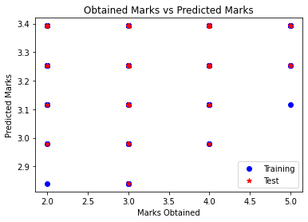

```python
plt.scatter(y_train, y_train_pred, c='blue', marker = 'o', label='Training')
plt.scatter(y_test, y_test_pred, c='red', marker = '*', label='Test')
plt.xlabel('Marks Obtained')
plt.ylabel('Predicted Marks')
plt.title('Obtained Marks vs Predicted Marks')
plt.legend(loc = 'lower right')
plt.plot()
plt.show()
```

```python
# find correlations and sort
df_out.corr()['grade4'].sort_values()
```

```
failures         -0.267943
schoolsup        -0.193265
alc_av_consump   -0.170312
Dalc             -0.167687
Walc             -0.144726
health           -0.113716
absences         -0.105147
paid             -0.090366
traveltime       -0.076286
goout            -0.072953
romantic         -0.053101
age              -0.031299
famsup           -0.023986
freetime         -0.006036
both_course       0.003528
activities        0.029025
ID                0.039383
famrel            0.061992
studytime         0.128579
internet          0.142007
G1                0.776908
G2                0.842516
G3                0.874571
grade4            1.000000
nursery                NaN
higher                 NaN
Name: grade4, dtype: float64
```

```python
# новые DF для просмотра наибольшей корреляции данных
df_x = pd.DataFrame(data, columns = ['studytime', 'failures',  'schoolsup','internet', 'famrel',
                                 'alc_av_consump'])

d_f = pd.DataFrame(y, columns = ['status'])

# убираю выбросы
Q1 = df_x.quantile(0.20)
Q3 = df_x.quantile(0.90)
IQR = Q3 - Q1

df_x = df_x[~((df_x < (Q1 - 1.5 * IQR)) |(df_x > (Q3 + 1.5 * IQR))).any(axis=1)]
print(df_x.shape)
```

```
(1014, 6)
```

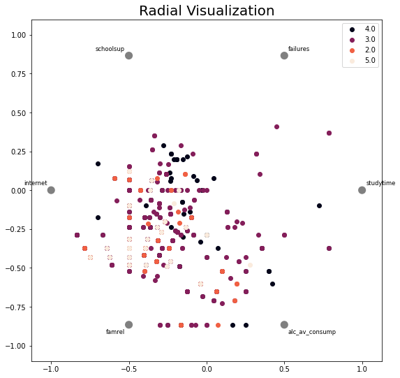

```python
np.seterr(divide='ignore', invalid='ignore')

from pandas.plotting import radviz
fig, ax = plt.subplots(figsize=(9, 9))
new_df = df_x.copy()
new_df["status"] = d_f
new_df = new_df.dropna()
radviz(new_df, "status", ax=ax, colormap="rocket")
plt.title('Radial Visualization', fontsize = 20)
plt.show()
```